# Lab 6

## Protected areas

8. The folder MPAs has a shapefile with polygons for Marine Protected Areas within the United States. This file was extracted from a file with all protected areas in the US [source](https://www.protectedplanet.net). Read the MPA shapefile.

```r
mpa <- vect("mpas.shp")
```

9. Now we will focus on just the US west coast. You can use the following longitude and latitude extent: xmin=-128, xmax=-115, ymin=32, ymax=40. Get just the MPAs on the US west coast by cropping the MPA dataset to this extent.

```r
#Hint: use the crop() function
west_ext <- ext(-128,-115,32,40)
mpa <- crop(mpa, west_ext)
```

10. Find the fraction of the blue whale observations that are in one of the west coast MPAs. You can use `is.related`

```r
inside <- is.related(bluew, mpa, "intersects")

frac_obs <- sum(inside) /nrow(bluew)
frac_obs
```

```
## [1] 0.1605661
```

```r
## 0.1605661
```

11. Find what fraction of blue whales in the dataset spend at least some time in one of these west coast MPAs.

```r
bluew$inside_mpa <- inside
whale_use <- tapply(bluew$inside_mpa, bluew$ind_ident, any)

frac_whales <- sum(whale_use) / length(whale_use)
frac_whales
```

```
## [1] 0.8439716
```

```r
## 0.8439716
```

```r
r <- rast(west_ext, res=1/6)
r <- rasterize(bluew, r, fun="count")
r
```

```
## class       : SpatRaster
## size        : 48, 78, 1  (nrow, ncol, nlyr)
## resolution  : 0.1666667, 0.1666667  (x, y)
## extent      : -128, -115, 32, 40  (xmin, xmax, ymin, ymax)
## coord. ref. : lon/lat WGS 84 (CRS84) (OGC:CRS84)
## source(s)   : memory
## name        : count
## min value   :     1
## max value   :   247
```

13. Make a map to show the counts and the MPAs and land areas. Plot 3 on Canvas shows you the plot you are aiming for.

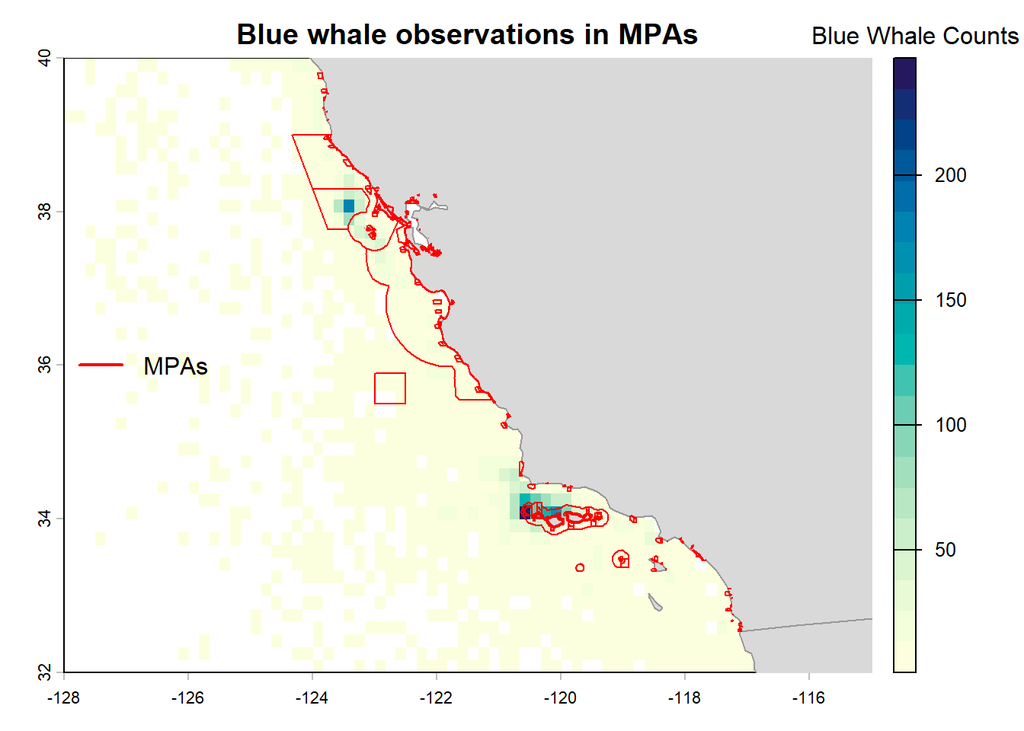

```r
plot(r,
     main="Blue whale observations in MPAs",
     col=hcl.colors(20, "YlGnBu", rev=TRUE),
     axes=TRUE,
     plg=list(title="Blue Whale Counts"))

coast <- crop(wrld, ext(r)+1)
plot(coast, col="gray85", border="gray60", add=TRUE)

plot(mpa, col=NA, border="red", lwd=1.2, add=TRUE)

legend("left",
       inset=c(0,-0.08),
       legend= "MPAs",
       col="red",
       lwd=2,
       bty="n",
       xpd=TRUE)
```

14. Using a subset of the country boundaries (to speed up computations), create a raster with the distance to the coast, using the raster with the number of observations as template.

```r
coast <- crop(wrld, ext(r)+1)
land_rast <- rasterize(coast, r)

dist_coast <- distance(land_rast)
dist_coast
```

```
## class       : SpatRaster
## size        : 48, 78, 1  (nrow, ncol, nlyr)
## resolution  : 0.1666667, 0.1666667  (x, y)
## extent      : -128, -115, 32, 40  (xmin, xmax, ymin, ymax)
## coord. ref. : lon/lat WGS 84 (CRS84) (OGC:CRS84)
## source(s)   : memory
## name        :    layer
## min value   :      0.0
## max value   : 732847.9
```

15. For each blue whale observation, find the distance to the coast based on this raster (you can use `terra::extract`). Make a histogram of the distribution.

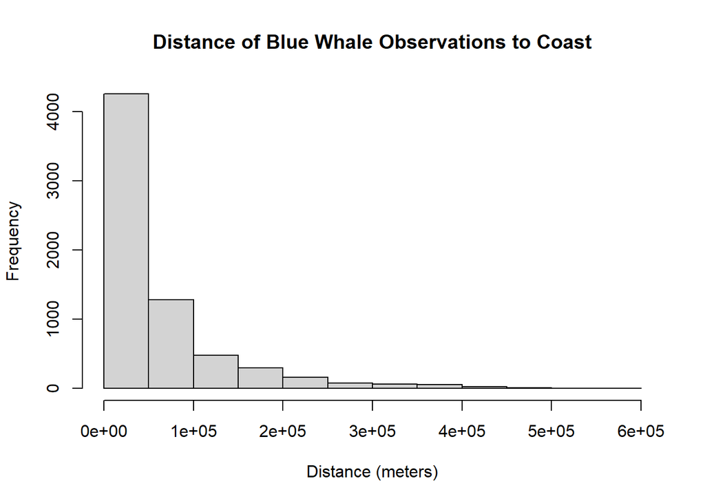

```r
dist_vals <- extract(dist_coast, bluew)
hist(dist_vals[,2],
     main="Distance of Blue Whale Observations to Coast",
     xlab="Distance (meters)")
```